# Route-3 Global Robustness: Multi-seed, Multi-scale, and Collision Audit

This notebook tests whether the frozen Notebook-10 **synthetic cortical-rate 14D** contract remains numerically stable across simulator seeds and parameter regimes. It does not train SNPE and does not use real EEG.

Pre-registered engineering gates:

- simulation failure rate at most 1%;
- at least 99% finite 14D vectors;
- invariant feature dimension and order;
- pickle-free artifacts with explicit simulator seeds.

Scientific warnings do not block the authorized exploratory pilot, but they must propagate into held-out GO/NO-GO interpretation.

```python
from __future__ import annotations
from datetime import datetime, timezone
import importlib.metadata as mdist
import json
import os
from pathlib import Path
import platform
import sys

import matplotlib.pyplot as plt
import nbformat
import numpy as np
import pandas as pd

PROJECT_ROOT = Path.cwd().resolve()
if not (PROJECT_ROOT / "S4_sbi" / "src").exists():
    for parent in PROJECT_ROOT.parents:
        if (parent / "S4_sbi" / "src").exists():
            PROJECT_ROOT = parent
            break
SRC = PROJECT_ROOT / "S4_sbi" / "src"
for path in (SRC, PROJECT_ROOT):
    if str(path) not in sys.path:
        sys.path.insert(0, str(path))

from sleep_sbi.route3_global_robustness import (
    COLLISION_NOISE_QUANTILE,
    COLLISION_THETA_RMS_THRESHOLD,
    GLOBAL_ROOT,
    GLOBAL_SIMULATOR_SEEDS,
    LOCAL_SCALES,
    RESULTS_ROOT,
    analyze_local_multiscale,
    analyze_prior_multiseed,
    engineering_gate,
    rate_contract_hash,
    rate_feature_names,
    run_local_multiscale,
    run_prior_multiseed,
)
from sleep_sbi.route3_synthetic_preflight import PARAMETER_NAMES, parameter_contract

FIGURE_DIR = GLOBAL_ROOT / "figures"
HTML_DIR = RESULTS_ROOT / "html"
FIGURE_DIR.mkdir(parents=True, exist_ok=True)
HTML_DIR.mkdir(parents=True, exist_ok=True)
environment = {
    "created_utc": datetime.now(timezone.utc).isoformat(),
    "conda_default_env": os.environ.get("CONDA_DEFAULT_ENV"),
    "sys_executable": sys.executable,
    "sys_prefix": sys.prefix,
    "python": platform.python_version(),
    "kernel_id": "neurolib",
    "sbi": mdist.version("sbi"),
    "torch": mdist.version("torch"),
    "neurolib": mdist.version("neurolib"),
    "cpu_count": os.cpu_count(),
}
assert Path(sys.prefix).name.lower() == "neurolib"
display(pd.DataFrame(environment.items(), columns=["item", "value"]))
```

|  | item | value |
| --- | --- | --- |
| 0 | created_utc | 2026-07-27T20:16:08.987574+00:00 |
| 1 | conda_default_env | neurolib |
| 2 | sys_executable | C:\Users\YUS190\AppData\Local\anaconda3\envs\n... |
| 3 | sys_prefix | C:\Users\YUS190\AppData\Local\anaconda3\envs\n... |
| 4 | python | 3.10.20 |
| 5 | kernel_id | neurolib |
| 6 | sbi | 0.26.1 |
| 7 | torch | 2.5.1 |
| 8 | neurolib | 0.6.1 |
| 9 | cpu_count | 20 |

## 1. Frozen schema and seed-control evidence

Feature definitions, order, units, Welch settings, warm-up, and 30-s window are unchanged from Notebook 10. Every stochastic input seed and the numba RNG are set to the recorded integer. A same-theta/same-seed repeat was exactly equal; changing only the seed changed 12 of 14 summaries.

```python
contract = parameter_contract()
feature_names = list(rate_feature_names())
assert len(feature_names) == 14 and len(set(feature_names)) == 14
seed_evidence = pd.DataFrame(
    [
        {"check": "same theta + same seed", "result": "max abs diff = 0"},
        {"check": "same theta + different seed", "result": "12/14 summaries changed"},
        {"check": "seeded inputs", "result": "ALN EXC, ALN INH, TCR, TRN plus numba RNG"},
    ]
)
display(pd.DataFrame({"index": range(14), "feature": feature_names}))
display(seed_evidence)
print("Rate contract hash:", rate_contract_hash())
```

|  | index | feature |
| --- | --- | --- |
| 0 | 0 | r_exc_mean_hz |
| 1 | 1 | r_exc_std_hz |
| 2 | 2 | r_exc_relative_so_power |
| 3 | 3 | r_exc_relative_sigma_power |
| 4 | 4 | r_exc_so_peak_frequency_hz |
| 5 | 5 | r_exc_sigma_peak_frequency_hz |
| 6 | 6 | r_exc_spectral_entropy_0p5_20 |
| 7 | 7 | r_inh_mean_hz |
| 8 | 8 | r_inh_std_hz |
| 9 | 9 | r_inh_relative_so_power |
| 10 | 10 | r_inh_relative_sigma_power |
| 11 | 11 | r_inh_so_peak_frequency_hz |
| 12 | 12 | r_inh_sigma_peak_frequency_hz |
| 13 | 13 | r_inh_spectral_entropy_0p5_20 |

|  | check | result |
| --- | --- | --- |
| 0 | same theta + same seed | max abs diff = 0 |
| 1 | same theta + different seed | 12/14 summaries changed |
| 2 | seeded inputs | ALN EXC, ALN INH, TCR, TRN plus numba RNG |

```
Rate contract hash: 78d0da704422a03917ef4c68207f5e8e8213b0c6f6279deaf26f34c9958d64a8
```

## 2. 128 theta x 3 simulator seeds

The 128 scrambled Sobol theta values are identical across three replicates. Replicates are retained separately; seed variation is never averaged away in the stored bank. The analysis decomposes within-theta seed variance and between-theta variance.

```python
prior_run = run_prior_multiseed(max_workers=6)
prior = analyze_prior_multiseed(prior_run["path"])
prior_summary = prior["summary"]
feature_noise = prior["feature_metrics"]
display(pd.DataFrame([prior_summary]))
display(feature_noise)
assert prior_summary["attempted"] == 384
assert prior_summary["success"] == 384
```

|  | attempted | success | failure_rate | fully_finite_rate | noise_floor_q95_robust_x_distance | nearest_neighbor_all_three_seed_agreement | nearest_neighbor_pair_agreement | collision_theta_rms_threshold | global_collision_count | near_collision_count |
| --- | --- | --- | --- | --- | --- | --- | --- | --- | --- | --- |
| 0 | 384 | 384 | 0.0 | 1.0 | 2.304823 | 0.289062 | {'seed_0_vs_1': 0.390625, 'seed_0_vs_2': 0.468... | 0.25 | 1469 | 3670 |

|  | feature | within_theta_seed_variance | between_theta_variance | between_to_within_snr | unique_values_min_across_seeds | quantized_or_degenerate_warning |
| --- | --- | --- | --- | --- | --- | --- |
| 0 | r_exc_mean_hz | 0.003943 | 4.531038 | 1149.230683 | 128 | False |
| 1 | r_exc_std_hz | 0.008026 | 3.766312 | 469.274430 | 128 | False |
| 2 | r_exc_relative_so_power | 0.000107 | 0.026211 | 245.763835 | 128 | False |
| 3 | r_exc_relative_sigma_power | 0.000005 | 0.001162 | 232.349302 | 128 | False |
| 4 | r_exc_so_peak_frequency_hz | 0.004395 | 0.084932 | 19.326820 | 5 | True |
| 5 | r_exc_sigma_peak_frequency_hz | 0.277832 | 0.424252 | 1.527009 | 12 | True |
| 6 | r_exc_spectral_entropy_0p5_20 | 0.000087 | 0.003082 | 35.336356 | 128 | False |
| 7 | r_inh_mean_hz | 0.051846 | 89.087358 | 1718.304041 | 128 | False |
| 8 | r_inh_std_hz | 0.018118 | 7.109376 | 392.387209 | 128 | False |
| 9 | r_inh_relative_so_power | 0.000186 | 0.043458 | 233.735885 | 128 | False |
| 10 | r_inh_relative_sigma_power | 0.000006 | 0.002018 | 352.785092 | 128 | False |
| 11 | r_inh_so_peak_frequency_hz | 0.002930 | 0.090770 | 30.982794 | 5 | True |
| 12 | r_inh_sigma_peak_frequency_hz | 0.241862 | 0.758478 | 3.135997 | 13 | True |
| 13 | r_inh_spectral_entropy_0p5_20 | 0.000112 | 0.005803 | 51.656109 | 128 | False |

### Seed-noise signal-to-noise and quantization

`between_to_within_snr` compares variation of theta-specific means against replicate seed variance. It is not posterior information. Frequencies inherit the frozen 0.25-Hz Welch grid, so low unique-value counts identify quantization.

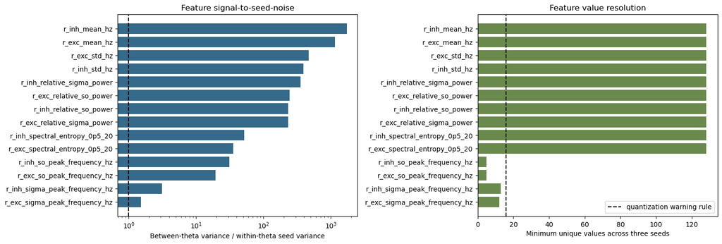

```python
fig, axes = plt.subplots(1, 2, figsize=(15, 5), constrained_layout=True)
ordered = feature_noise.sort_values("between_to_within_snr")
axes[0].barh(ordered["feature"], ordered["between_to_within_snr"], color="#356a8a")
axes[0].set_xscale("log")
axes[0].axvline(1, color="black", ls="--")
axes[0].set(xlabel="Between-theta variance / within-theta seed variance", title="Feature signal-to-seed-noise")
axes[1].barh(ordered["feature"], ordered["unique_values_min_across_seeds"], color="#6a8a4d")
axes[1].axvline(16, color="black", ls="--", label="quantization warning rule")
axes[1].set(xlabel="Minimum unique values across three seeds", title="Feature value resolution")
axes[1].legend()
fig.savefig(FIGURE_DIR / "feature_seed_snr_and_quantization.png", dpi=180)
fig.savefig(FIGURE_DIR / "feature_seed_snr_and_quantization.svg")
plt.show()
```

### Nearest-neighbor stability

For each seed, nearest neighbors are computed after robust scaling on this synthetic experiment. Low agreement means simulator noise and nonlinear feature geometry can change which theta appears closest. This is not itself a collision proof, but it is a warning for density estimation.

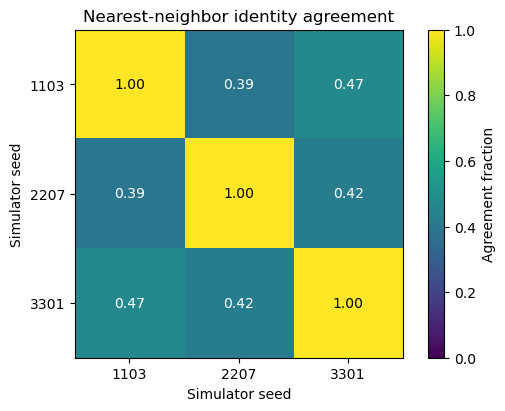

```python
nearest = prior["nearest"]
agreement = np.mean(nearest[:, :, None] == nearest[:, None, :], axis=1)
fig, ax = plt.subplots(figsize=(6, 4), constrained_layout=True)
matrix = np.array(
    [
        [1.0, prior_summary["nearest_neighbor_pair_agreement"]["seed_0_vs_1"], prior_summary["nearest_neighbor_pair_agreement"]["seed_0_vs_2"]],
        [prior_summary["nearest_neighbor_pair_agreement"]["seed_0_vs_1"], 1.0, prior_summary["nearest_neighbor_pair_agreement"]["seed_1_vs_2"]],
        [prior_summary["nearest_neighbor_pair_agreement"]["seed_0_vs_2"], prior_summary["nearest_neighbor_pair_agreement"]["seed_1_vs_2"], 1.0],
    ]
)
image = ax.imshow(matrix, vmin=0, vmax=1, cmap="viridis")
ax.set_xticks(range(3), GLOBAL_SIMULATOR_SEEDS)
ax.set_yticks(range(3), GLOBAL_SIMULATOR_SEEDS)
ax.set(xlabel="Simulator seed", ylabel="Simulator seed", title="Nearest-neighbor identity agreement")
for i in range(3):
    for j in range(3):
        ax.text(j, i, f"{matrix[i,j]:.2f}", ha="center", va="center", color="white" if matrix[i,j] < .6 else "black")
fig.colorbar(image, ax=ax, label="Agreement fraction")
fig.savefig(FIGURE_DIR / "nearest_neighbor_seed_agreement.png", dpi=180)
fig.savefig(FIGURE_DIR / "nearest_neighbor_seed_agreement.svg")
plt.show()
```

## 3. Multi-scale local Jacobians

At V7, V8, and V8a theta centers, central differences use 1%, 2%, and 5% of prior width under three seeds. All runs use the same V8a dynamics contract; the center labels refer to theta, not different extractor implementations.

Effective rank remains pre-frozen as (\sigma_k/\sigma_1 \ge 10^{-3}).

```python
local_run = run_local_multiscale(max_workers=6)
local = analyze_local_multiscale(local_run["path"])
rank = local["rank"]
target_cosines = local["target_cosines"]
direction = local["seed_direction_consistency"]
local_summary = local["summary"].iloc[0].to_dict()
display(rank.groupby(["center", "scale"]).agg(
    rank_min=("effective_rank", "min"),
    rank_max=("effective_rank", "max"),
    condition_median=("condition_number", "median"),
    condition_max=("condition_number", "max"),
))
assert len(rank) == 27
```

| center | scale | rank_min | rank_max | condition_median | condition_max |
| --- | --- | --- | --- | --- | --- |
| v7_fitted | 0.01 | 8 | 8 | 55.011297 | 80.934474 |
|  | 0.02 | 8 | 8 | 29.679955 | 38.870754 |
|  | 0.05 | 8 | 8 | 36.991951 | 41.550351 |
| v8_fitted | 0.01 | 8 | 8 | 45.199058 | 67.382357 |
|  | 0.02 | 8 | 8 | 47.835696 | 48.897983 |
|  | 0.05 | 8 | 8 | 27.033618 | 34.282012 |
| v8a_local_best | 0.01 | 8 | 8 | 42.626099 | 44.429693 |
|  | 0.02 | 8 | 8 | 38.322962 | 73.370611 |
|  | 0.05 | 8 | 8 | 40.598400 | 51.518219 |

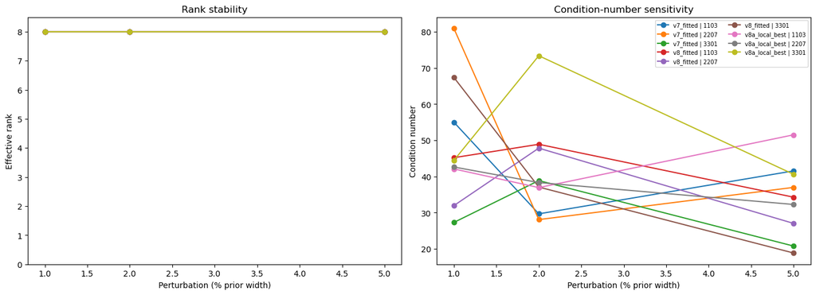

```python
fig, axes = plt.subplots(1, 2, figsize=(14, 5), constrained_layout=True)
for center in rank["center"].unique():
    subset = rank[rank.center == center]
    for seed in GLOBAL_SIMULATOR_SEEDS:
        row = subset[subset.seed == seed]
        axes[0].plot(row.scale * 100, row.effective_rank, marker="o", label=f"{center} | {seed}")
        axes[1].plot(row.scale * 100, row.condition_number, marker="o", label=f"{center} | {seed}")
axes[0].set(xlabel="Perturbation (% prior width)", ylabel="Effective rank", title="Rank stability", ylim=(0, 8.5))
axes[1].set(xlabel="Perturbation (% prior width)", ylabel="Condition number", title="Condition-number sensitivity")
axes[1].legend(fontsize=7, ncol=2)
fig.savefig(FIGURE_DIR / "multiscale_rank_condition.png", dpi=180)
fig.savefig(FIGURE_DIR / "multiscale_rank_condition.svg")
plt.show()
```

### Targeted parameter confounding

Cosines near +1 or -1 indicate parallel or anti-parallel Jacobian columns. Results are shown separately for each seed and scale; the wide variation is scientifically relevant rather than averaged away.

| center | scale | parameter_a | parameter_b | min | median | max |
| --- | --- | --- | --- | --- | --- | --- |
| v7_fitted | 0.01 | c_th2ctx | c_ctx2th | -0.197752 | -0.031329 | -0.007893 |
|  |  | g_LK | g_h | 0.132427 | 0.146291 | 0.700815 |
|  | 0.02 | c_th2ctx | c_ctx2th | -0.561103 | -0.292867 | 0.109157 |
|  |  | g_LK | g_h | -0.778856 | -0.466056 | -0.328499 |
|  | 0.05 | c_th2ctx | c_ctx2th | -0.605768 | -0.386317 | 0.619099 |
|  |  | g_LK | g_h | -0.103684 | 0.032912 | 0.039393 |
| v8_fitted | 0.01 | c_th2ctx | c_ctx2th | 0.044681 | 0.329322 | 0.514388 |
|  |  | g_LK | g_h | 0.008620 | 0.120933 | 0.946764 |
|  | 0.02 | c_th2ctx | c_ctx2th | -0.095877 | 0.182294 | 0.636572 |
|  |  | g_LK | g_h | 0.648385 | 0.704120 | 0.907462 |
|  | 0.05 | c_th2ctx | c_ctx2th | 0.208331 | 0.426515 | 0.762133 |
|  |  | g_LK | g_h | 0.907670 | 0.939987 | 0.949785 |
| v8a_local_best | 0.01 | c_th2ctx | c_ctx2th | -0.849974 | 0.121248 | 0.700553 |
|  |  | g_LK | g_h | -0.649128 | 0.109426 | 0.356682 |
|  | 0.02 | c_th2ctx | c_ctx2th | -0.779983 | -0.076083 | 0.928124 |
|  |  | g_LK | g_h | 0.228884 | 0.649650 | 0.902581 |
|  | 0.05 | c_th2ctx | c_ctx2th | 0.448208 | 0.782527 | 0.799162 |
|  |  | g_LK | g_h | 0.723698 | 0.758648 | 0.909602 |

|  | center | scale | parameter | seed_a | seed_b | direction_cosine |
| --- | --- | --- | --- | --- | --- | --- |
| 7 | v7_fitted | 0.01 | b | 1103 | 3301 | -0.962848 |
| 167 | v8a_local_best | 0.01 | c_ctx2th | 2207 | 3301 | -0.856679 |
| 18 | v7_fitted | 0.01 | c_th2ctx | 1103 | 2207 | -0.839891 |
| 190 | v8a_local_best | 0.02 | c_ctx2th | 1103 | 3301 | -0.756173 |
| 20 | v7_fitted | 0.01 | c_th2ctx | 2207 | 3301 | -0.750814 |
| 101 | v8_fitted | 0.02 | mui | 2207 | 3301 | -0.720549 |
| 106 | v8_fitted | 0.02 | tauA | 1103 | 3301 | -0.717117 |
| 82 | v8_fitted | 0.01 | tauA | 1103 | 3301 | -0.700250 |
| 145 | v8a_local_best | 0.01 | mue | 1103 | 3301 | -0.683532 |
| 56 | v7_fitted | 0.05 | b | 2207 | 3301 | -0.667108 |
| 143 | v8_fitted | 0.05 | c_ctx2th | 2207 | 3301 | -0.666309 |
| 72 | v8_fitted | 0.01 | mue | 1103 | 2207 | -0.645250 |
| 139 | v8_fitted | 0.05 | c_th2ctx | 1103 | 3301 | -0.630699 |
| 154 | v8a_local_best | 0.01 | tauA | 1103 | 3301 | -0.625698 |
| 8 | v7_fitted | 0.01 | b | 2207 | 3301 | -0.623124 |
| 78 | v8_fitted | 0.01 | b | 1103 | 2207 | -0.608167 |
| 157 | v8a_local_best | 0.01 | g_LK | 1103 | 3301 | -0.598684 |
| 140 | v8_fitted | 0.05 | c_th2ctx | 2207 | 3301 | -0.591152 |
| 158 | v8a_local_best | 0.01 | g_LK | 2207 | 3301 | -0.589825 |
| 43 | v7_fitted | 0.02 | c_th2ctx | 1103 | 3301 | -0.583696 |

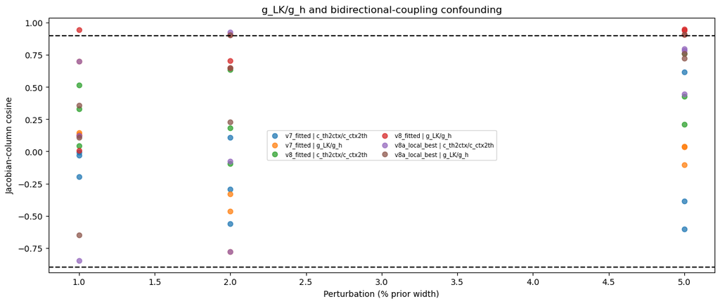

```python
display(target_cosines.groupby(["center", "scale", "parameter_a", "parameter_b"]).cosine.agg(["min", "median", "max"]))
worst_directions = direction.sort_values("direction_cosine").head(20)
display(worst_directions)
fig, ax = plt.subplots(figsize=(12, 5), constrained_layout=True)
for (center, pair), subset in target_cosines.assign(
    pair=target_cosines.parameter_a + "/" + target_cosines.parameter_b
).groupby(["center", "pair"]):
    ax.scatter(subset.scale * 100, subset.cosine, label=f"{center} | {pair}", alpha=.75)
ax.axhline(.9, color="black", ls="--")
ax.axhline(-.9, color="black", ls="--")
ax.set(xlabel="Perturbation (% prior width)", ylabel="Jacobian-column cosine", title="g_LK/g_h and bidirectional-coupling confounding")
ax.legend(fontsize=7, ncol=2)
fig.savefig(FIGURE_DIR / "target_parameter_confounds.png", dpi=180)
fig.savefig(FIGURE_DIR / "target_parameter_confounds.svg")
plt.show()
```

## 4. Global-collision audit

Pre-registered definitions:

- theta distance is Euclidean distance after prior-width scaling, divided by (\sqrt{8});
- x uses median/IQR robust scaling fitted only on the 384 synthetic rows;
- the observable noise floor is the 95th percentile of same-theta replicate distances;
- a far pair requires theta RMS distance at least 0.25;
- `collision`: x distance at or below the noise floor;
- `near collision`: x distance between one and two noise floors.

Collisions indicate seed-induced overlap or global folding. They are distinct from feature-feature correlation and do not contradict a locally full-rank Jacobian.

|  | attempted | success | failure_rate | fully_finite_rate | noise_floor_q95_robust_x_distance | nearest_neighbor_all_three_seed_agreement | nearest_neighbor_pair_agreement | collision_theta_rms_threshold | global_collision_count | near_collision_count |
| --- | --- | --- | --- | --- | --- | --- | --- | --- | --- | --- |
| 0 | 384 | 384 | 0.0 | 1.0 | 2.304823 | 0.289062 | {'seed_0_vs_1': 0.390625, 'seed_0_vs_2': 0.468... | 0.25 | 1469 | 3670 |

|  | theta_id_a | theta_id_b | theta_rms_distance | x_distance | noise_floor_q95 | severity_ratio_x_to_noise | delta_mue_prior_width | delta_mui_prior_width | delta_b_prior_width | delta_tauA_prior_width | delta_g_LK_prior_width | delta_g_h_prior_width | delta_c_th2ctx_prior_width | delta_c_ctx2th_prior_width |
| --- | --- | --- | --- | --- | --- | --- | --- | --- | --- | --- | --- | --- | --- | --- |
| 56 | 3 | 89 | 0.340504 | 0.415408 | 2.304823 | 0.180234 | -0.319900 | 0.030047 | -0.032763 | -0.409716 | 0.228368 | -0.077589 | -0.054313 | 0.770870 |
| 521 | 29 | 85 | 0.306748 | 0.479679 | 2.304823 | 0.208120 | -0.170578 | -0.088204 | 0.136353 | -0.214994 | 0.100998 | 0.074892 | -0.055602 | 0.795088 |
| 41 | 3 | 17 | 0.325079 | 0.487412 | 2.304823 | 0.211475 | -0.524321 | -0.022374 | 0.048658 | -0.616872 | 0.392599 | -0.123180 | 0.123729 | 0.049849 |
| 308 | 17 | 89 | 0.290409 | 0.491835 | 2.304823 | 0.213394 | 0.204422 | 0.052421 | -0.081421 | 0.207156 | -0.164230 | 0.045591 | -0.178042 | 0.721021 |
| 605 | 31 | 115 | 0.369308 | 0.522335 | 2.304823 | 0.226627 | -0.358550 | 0.078037 | -0.166384 | -0.490021 | 0.343409 | -0.532040 | -0.144978 | -0.516375 |
| 1196 | 72 | 84 | 0.380825 | 0.527450 | 2.304823 | 0.228846 | -0.097987 | -0.150582 | -0.125065 | -0.023107 | 0.775905 | 0.326481 | 0.591169 | -0.231674 |
| 855 | 46 | 60 | 0.476884 | 0.543810 | 2.304823 | 0.235944 | 0.493499 | 0.039891 | 0.045114 | 0.648127 | 0.607450 | -0.127123 | 0.874225 | -0.051832 |
| 364 | 20 | 48 | 0.397740 | 0.550257 | 2.304823 | 0.238742 | 0.224258 | -0.115809 | 0.055651 | 0.240064 | 0.444630 | -0.673710 | 0.653094 | -0.251064 |
| 1109 | 65 | 119 | 0.503665 | 0.591635 | 2.304823 | 0.256694 | 0.716511 | 0.108825 | -0.115914 | 0.892195 | 0.573494 | -0.453802 | 0.222718 | -0.332136 |
| 637 | 33 | 51 | 0.501381 | 0.606839 | 2.304823 | 0.263291 | 0.520413 | -0.037991 | -0.049084 | 0.399112 | -0.888706 | 0.121860 | -0.875660 | 0.075243 |
| 1322 | 89 | 125 | 0.309865 | 0.637119 | 2.304823 | 0.276429 | 0.276751 | -0.130397 | 0.067392 | 0.240323 | 0.446000 | 0.486456 | 0.338611 | -0.249050 |
| 721 | 39 | 75 | 0.342160 | 0.651516 | 2.304823 | 0.282675 | -0.108250 | 0.078274 | 0.206660 | -0.517303 | 0.150912 | -0.532040 | -0.269238 | 0.479688 |
| 3 | 0 | 56 | 0.273422 | 0.671000 | 2.304823 | 0.291129 | -0.133098 | -0.281614 | 0.069260 | -0.357274 | 0.291691 | -0.124565 | 0.064304 | 0.513691 |
| 1039 | 60 | 85 | 0.456540 | 0.675687 | 2.304823 | 0.293162 | -0.242906 | 0.205120 | 0.067355 | -0.256826 | -0.555057 | 0.413161 | -0.433507 | 0.910572 |
| 622 | 32 | 88 | 0.256144 | 0.683841 | 2.304823 | 0.296700 | -0.112775 | -0.053559 | -0.101410 | -0.113803 | 0.373041 | 0.107407 | 0.490084 | -0.308512 |
| 20 | 2 | 32 | 0.369552 | 0.687350 | 2.304823 | 0.298222 | 0.418852 | 0.022719 | 0.072345 | 0.461629 | -0.614238 | -0.029807 | -0.560021 | 0.080366 |
| 635 | 33 | 45 | 0.270769 | 0.698716 | 2.304823 | 0.303154 | 0.315436 | -0.050797 | 0.201394 | 0.242814 | -0.569534 | 0.213244 | -0.059243 | 0.107598 |
| 85 | 4 | 106 | 0.296114 | 0.699725 | 2.304823 | 0.303592 | -0.371251 | 0.200162 | 0.172694 | -0.599731 | 0.241102 | -0.026005 | 0.069374 | 0.265434 |
| 508 | 29 | 41 | 0.316953 | 0.710195 | 2.304823 | 0.308134 | -0.299966 | 0.144159 | 0.224859 | -0.509601 | -0.015126 | 0.096752 | 0.126281 | 0.597598 |
| 1003 | 58 | 65 | 0.324956 | 0.711386 | 2.304823 | 0.308651 | -0.250594 | 0.262710 | 0.106128 | -0.391408 | -0.071921 | 0.292141 | -0.075578 | 0.672507 |

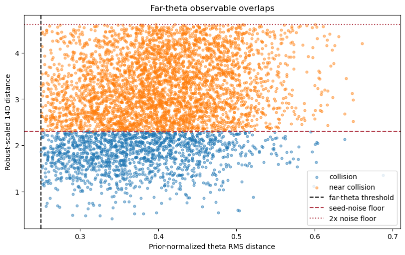

```python
collisions = prior["collisions"]
near_collisions = prior["near_collisions"]
display(pd.DataFrame([prior_summary]))
display(collisions.sort_values("severity_ratio_x_to_noise").head(20))

all_pairs = pd.concat(
    [
        collisions.assign(classification="collision"),
        near_collisions.assign(classification="near collision"),
    ],
    ignore_index=True,
)
fig, ax = plt.subplots(figsize=(8, 5), constrained_layout=True)
for label, subset in all_pairs.groupby("classification"):
    ax.scatter(subset.theta_rms_distance, subset.x_distance, s=12, alpha=.45, label=label)
ax.axvline(COLLISION_THETA_RMS_THRESHOLD, color="black", ls="--", label="far-theta threshold")
ax.axhline(prior_summary["noise_floor_q95_robust_x_distance"], color="#b23a48", ls="--", label="seed-noise floor")
ax.axhline(2 * prior_summary["noise_floor_q95_robust_x_distance"], color="#b23a48", ls=":", label="2x noise floor")
ax.set(xlabel="Prior-normalized theta RMS distance", ylabel="Robust-scaled 14D distance", title="Far-theta observable overlaps")
ax.legend()
fig.savefig(FIGURE_DIR / "global_collision_audit.png", dpi=180)
fig.savefig(FIGURE_DIR / "global_collision_audit.svg")
plt.show()
```

## 5. Engineering gate and preregistered warnings

The engineering gate controls whether bank generation can start. Passing it does not establish global identifiability. The collision count, low nearest-neighbor stability, quantized peak frequencies, and seed/scale sensitivity are carried forward unchanged into held-out validation.

```python
gate = engineering_gate(prior_summary, local_summary)
warnings_table = pd.DataFrame(
    [
        {"warning": "far-theta collisions within seed-noise floor", "value": prior_summary["global_collision_count"]},
        {"warning": "near collisions within two noise floors", "value": prior_summary["near_collision_count"]},
        {"warning": "all-three-seed nearest-neighbor agreement", "value": prior_summary["nearest_neighbor_all_three_seed_agreement"]},
        {"warning": "minimum feature SNR", "value": feature_noise["between_to_within_snr"].min()},
        {"warning": "minimum local rank", "value": rank["effective_rank"].min()},
    ]
)
display(pd.DataFrame([gate]))
display(warnings_table)
assert gate["pass"]
```

|  | failure_rate_threshold | finite_rate_threshold | observed_max_failure_rate | observed_prior_finite_rate | feature_dimension_stable | feature_order_stable | seed_recorded_and_reproducible | pass |
| --- | --- | --- | --- | --- | --- | --- | --- | --- |
| 0 | 0.01 | 0.99 | 0.0 | 1.0 | True | True | True | True |

|  | warning | value |
| --- | --- | --- |
| 0 | far-theta collisions within seed-noise floor | 1469.000000 |
| 1 | near collisions within two noise floors | 3670.000000 |
| 2 | all-three-seed nearest-neighbor agreement | 0.289062 |
| 3 | minimum feature SNR | 1.527009 |
| 4 | minimum local rank | 8.000000 |

## 6. Artifact reload and conclusion

**Engineering PASS:** 825/825 simulations completed with fixed 14D order and no non-finite rows. This authorizes the pre-specified 2,048-point exploratory bank.

**Scientific warning:** local rank 8 is not global injectivity. Seed noise, global collisions, quantized peak frequencies, and parameter-ridge behavior must be adjudicated by held-out recovery, coverage, SBC, and PPC. No real-EEG inference is unlocked.

```python
prior_path = Path(prior_run["path"])
local_path = Path(local_run["path"])
for path, expected_shape in ((prior_path, (384, 14)), (local_path, (441, 14))):
    with np.load(path, allow_pickle=False) as data:
        assert data["x"].shape == expected_shape
        assert list(data["feature_names"]) == feature_names
        assert not [name for name in data.files if data[name].dtype == object]
        assert data["success"].all()
        assert np.isfinite(data["x"]).all()
report = {
    "created_utc": datetime.now(timezone.utc).isoformat(),
    "engineering_gate": gate,
    "prior_multiseed": prior_summary,
    "local_multiscale": local_summary,
    "pre_registered_scientific_warnings": warnings_table.to_dict("records"),
    "decision": "Proceed to authorized 2048-point exploratory bank; identifiability not established.",
    "real_eeg_inference_unlocked": False,
}
(GLOBAL_ROOT / "notebook11_validation.json").write_text(json.dumps(report, indent=2), encoding="utf-8")
print(json.dumps(report, indent=2))
```

```
{
  "created_utc": "2026-07-27T20:16:16.932935+00:00",
  "engineering_gate": {
    "failure_rate_threshold": 0.01,
    "finite_rate_threshold": 0.99,
    "observed_max_failure_rate": 0.0,
    "observed_prior_finite_rate": 1.0,
    "feature_dimension_stable": true,
    "feature_order_stable": true,
    "seed_recorded_and_reproducible": true,
    "pass": true
  },
  "prior_multiseed": {
    "attempted": 384,
    "success": 384,
    "failure_rate": 0.0,
    "fully_finite_rate": 1.0,
    "noise_floor_q95_robust_x_distance": 2.3048234774636587,
    "nearest_neighbor_all_three_seed_agreement": 0.2890625,
    "nearest_neighbor_pair_agreement": {
      "seed_0_vs_1": 0.390625,
      "seed_0_vs_2": 0.46875,
      "seed_1_vs_2": 0.421875
    },
    "collision_theta_rms_threshold": 0.25,
    "global_collision_count": 1469,
    "near_collision_count": 3670
  },
  "local_multiscale": {
    "attempted": 441,
    "success": 441,
    "failure_rate": 0.0,
    "rank_min": 8,
    "rank_max": 8,
    "all_full_rank": true
  },
  "pre_registered_scientific_warnings": [
    {
      "warning": "far-theta collisions within seed-noise floor",
      "value": 1469.0
    },
    {
      "warning": "near collisions within two noise floors",
      "value": 3670.0
    },
    {
      "warning": "all-three-seed nearest-neighbor agreement",
      "value": 0.2890625
    },
    {
      "warning": "minimum feature SNR",
      "value": 1.5270085966846427
    },
    {
      "warning": "minimum local rank",
      "value": 8.0
    }
  ],
  "decision": "Proceed to authorized 2048-point exploratory bank; identifiability not established.",
  "real_eeg_inference_unlocked": false
}
```